BLOQUE 1 DE 6

Por qué reducir

Cuando hay demasiadas variables para mirarlas.

# Aprendizaje no supervisado: no hay qué predecir

- Hasta ahora tuvimos siempre una variable respuesta $Y$. Acá **no la hay**: solo un conjunto de features $X_1,\dots,X_p$.
- El objetivo cambia: ya no es predecir, es descubrir estructura en los datos.
- Por eso el análisis no supervisado casi siempre es parte de un **análisis exploratorio**.
- Y por eso mismo es más **subjetivo**: no hay una respuesta correcta contra la cual validar, ni test set que nos diga si acertamos.

ISLP, Sección 12.1.

# Agrupar clientes que nadie etiquetó

Un caso cotidiano

Un sitio de compras online quiere recomendarle a cada persona lo que le interesa. Agrupa a sus clientes según su **historial de navegación y compra**, sin que nadie haya dicho de antemano a qué grupo pertenece cada uno.

- Nadie definió los grupos: **emergen de los datos**.
- Un buscador hace lo mismo con historiales de clics para decidir qué resultados mostrar.
- PCA ataca una versión de ese problema: cuando hay **muchas variables correlacionadas**, resumirlas en unas pocas que conserven casi toda la variabilidad.

# Varias variables dicen casi lo mismo

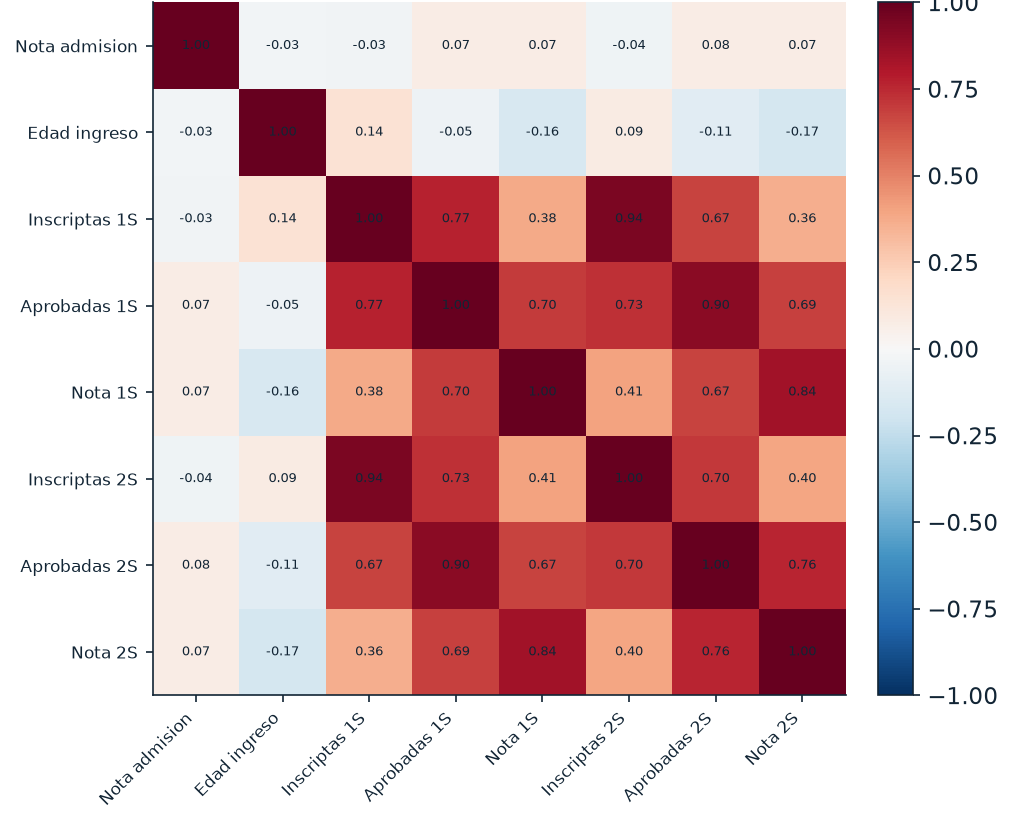

Correlaciones del bloque académico. Las materias **aprobadas en 1er y 2do semestre** correlacionan **0,90**: quien aprueba mucho en un semestre aprueba mucho en el otro. Hay redundancia para explotar.

# Con 8 variables ya hay 28 gráficos posibles

- Para mirar las relaciones de a pares hacen falta $p(p-1)/2$ diagramas de dispersión.
- Con nuestras **8 variables** son **28** gráficos. Con las **24** columnas numéricas del dataset, 276.
- Ninguno muestra la foto completa: cada uno contiene solo una fracción de la información.

La pregunta que abre PCA

¿Existe una representación de **pocas dimensiones** que capture la mayor parte posible de la variabilidad de los datos?

# De 4.500 adjetivos a cinco factores

- En 1936, Allport y Odbert listaron **4.500 términos** que describen diferencias de personalidad.
- Con análisis factorial (el pariente cercano de PCA), esos términos se redujeron primero a 16 y finalmente a cinco: el modelo **Big Five** (OCEAN).
- De Raad y Barelds (2008) aplicaron PCA a **2.365 ítems** del léxico holandés y recuperaron el Big Five más tres factores adicionales.

El principio, en una línea

Con $p$ enorme, unas pocas **dimensiones compuestas** pueden resumir una variedad inmensa. Es exactamente lo que vamos a hacer hoy, en menor escala.